# Risk Factor Analysis

## Outcome Variable

**Outcome Variable:** ever_stunted

## Predictor Variables

**Intervention Variable:** mwtkg

**Adjustment Set:**

unadjusted

## Stratifying Variables

The analysis was stratified on these variable(s):

- agecat
- studyid
- country

## Data Summary

| agecat | studyid | country | A | n | nA | nAY0 | nAY1 |
| --- | --- | --- | --- | --- | --- | --- | --- |
| 3 months | ki0047075b-MAL-ED | BANGLADESH | >=57.5 | 254 | 51 | 40 | 11 |
| 3 months | ki0047075b-MAL-ED | BANGLADESH | <42.5 | 254 | 55 | 35 | 20 |
| 3 months | ki0047075b-MAL-ED | BANGLADESH | [42.5-50) | 254 | 89 | 60 | 29 |
| 3 months | ki0047075b-MAL-ED | BANGLADESH | [50-57.5) | 254 | 59 | 47 | 12 |
| 3 months | ki0047075b-MAL-ED | BRAZIL | >=57.5 | 221 | 144 | 122 | 22 |
| 3 months | ki0047075b-MAL-ED | BRAZIL | <42.5 | 221 | 14 | 10 | 4 |
| 3 months | ki0047075b-MAL-ED | BRAZIL | [42.5-50) | 221 | 19 | 16 | 3 |
| 3 months | ki0047075b-MAL-ED | BRAZIL | [50-57.5) | 221 | 44 | 39 | 5 |
| 3 months | ki0047075b-MAL-ED | INDIA | >=57.5 | 242 | 44 | 37 | 7 |
| 3 months | ki0047075b-MAL-ED | INDIA | <42.5 | 242 | 47 | 32 | 15 |
| 3 months | ki0047075b-MAL-ED | INDIA | [42.5-50) | 242 | 76 | 53 | 23 |
| 3 months | ki0047075b-MAL-ED | INDIA | [50-57.5) | 242 | 75 | 55 | 20 |
| 3 months | ki0047075b-MAL-ED | NEPAL | >=57.5 | 238 | 87 | 73 | 14 |
| 3 months | ki0047075b-MAL-ED | NEPAL | <42.5 | 238 | 2 | 2 | 0 |
| 3 months | ki0047075b-MAL-ED | NEPAL | [42.5-50) | 238 | 50 | 36 | 14 |
| 3 months | ki0047075b-MAL-ED | NEPAL | [50-57.5) | 238 | 99 | 90 | 9 |
| 3 months | ki0047075b-MAL-ED | PERU | >=57.5 | 290 | 104 | 76 | 28 |
| 3 months | ki0047075b-MAL-ED | PERU | <42.5 | 290 | 14 | 7 | 7 |
| 3 months | ki0047075b-MAL-ED | PERU | [42.5-50) | 290 | 57 | 33 | 24 |
| 3 months | ki0047075b-MAL-ED | PERU | [50-57.5) | 290 | 115 | 74 | 41 |
| 3 months | ki0047075b-MAL-ED | SOUTH AFRICA | >=57.5 | 270 | 194 | 147 | 47 |
| 3 months | ki0047075b-MAL-ED | SOUTH AFRICA | <42.5 | 270 | 3 | 0 | 3 |
| 3 months | ki0047075b-MAL-ED | SOUTH AFRICA | [42.5-50) | 270 | 16 | 11 | 5 |
| 3 months | ki0047075b-MAL-ED | SOUTH AFRICA | [50-57.5) | 270 | 57 | 40 | 17 |
| 3 months | ki0047075b-MAL-ED | TANZANIA, UNITED REPUBLIC OF | >=57.5 | 256 | 103 | 79 | 24 |
| 3 months | ki0047075b-MAL-ED | TANZANIA, UNITED REPUBLIC OF | <42.5 | 256 | 9 | 3 | 6 |
| 3 months | ki0047075b-MAL-ED | TANZANIA, UNITED REPUBLIC OF | [42.5-50) | 256 | 69 | 43 | 26 |
| 3 months | ki0047075b-MAL-ED | TANZANIA, UNITED REPUBLIC OF | [50-57.5) | 256 | 75 | 50 | 25 |
| 3 months | ki1000304b-SAS-CompFeed | INDIA | >=57.5 | 467 | 32 | 28 | 4 |
| 3 months | ki1000304b-SAS-CompFeed | INDIA | <42.5 | 467 | 102 | 61 | 41 |

[output cut: 278 more lines]

The following strata were considered:

- agecat: 12 months, studyid: ki0047075b-MAL-ED, country: BANGLADESH
- agecat: 12 months, studyid: ki0047075b-MAL-ED, country: BRAZIL
- agecat: 12 months, studyid: ki0047075b-MAL-ED, country: INDIA
- agecat: 12 months, studyid: ki0047075b-MAL-ED, country: NEPAL
- agecat: 12 months, studyid: ki0047075b-MAL-ED, country: PERU
- agecat: 12 months, studyid: ki0047075b-MAL-ED, country: SOUTH AFRICA
- agecat: 12 months, studyid: ki0047075b-MAL-ED, country: TANZANIA, UNITED REPUBLIC OF
- agecat: 12 months, studyid: ki1000304b-SAS-CompFeed, country: INDIA
- agecat: 12 months, studyid: ki1017093-NIH-Birth, country: BANGLADESH
- agecat: 12 months, studyid: ki1017093b-PROVIDE, country: BANGLADESH
- agecat: 12 months, studyid: ki1017093c-NIH-Crypto, country: BANGLADESH
- agecat: 12 months, studyid: ki1066203-TanzaniaChild2, country: TANZANIA, UNITED REPUBLIC OF
- agecat: 12 months, studyid: ki1112895-iLiNS-Zinc, country: BURKINA FASO
- agecat: 12 months, studyid: ki1119695-PROBIT, country: BELARUS
- agecat: 12 months, studyid: ki1126311-ZVITAMBO, country: ZIMBABWE
- agecat: 12 months, studyid: ki1148112-LCNI-5, country: MALAWI
- agecat: 18 months, studyid: ki0047075b-MAL-ED, country: BANGLADESH
- agecat: 18 months, studyid: ki0047075b-MAL-ED, country: BRAZIL
- agecat: 18 months, studyid: ki0047075b-MAL-ED, country: INDIA
- agecat: 18 months, studyid: ki0047075b-MAL-ED, country: NEPAL
- agecat: 18 months, studyid: ki0047075b-MAL-ED, country: PERU
- agecat: 18 months, studyid: ki0047075b-MAL-ED, country: SOUTH AFRICA
- agecat: 18 months, studyid: ki0047075b-MAL-ED, country: TANZANIA, UNITED REPUBLIC OF
- agecat: 18 months, studyid: ki1000304b-SAS-CompFeed, country: INDIA
- agecat: 18 months, studyid: ki1017093-NIH-Birth, country: BANGLADESH
- agecat: 18 months, studyid: ki1017093b-PROVIDE, country: BANGLADESH
- agecat: 18 months, studyid: ki1017093c-NIH-Crypto, country: BANGLADESH
- agecat: 18 months, studyid: ki1066203-TanzaniaChild2, country: TANZANIA, UNITED REPUBLIC OF
- agecat: 18 months, studyid: ki1112895-iLiNS-Zinc, country: BURKINA FASO
- agecat: 18 months, studyid: ki1119695-PROBIT, country: BELARUS
- agecat: 18 months, studyid: ki1126311-ZVITAMBO, country: ZIMBABWE
- agecat: 18 months, studyid: ki1148112-LCNI-5, country: MALAWI
- agecat: 24 months, studyid: ki0047075b-MAL-ED, country: BANGLADESH
- agecat: 24 months, studyid: ki0047075b-MAL-ED, country: BRAZIL
- agecat: 24 months, studyid: ki0047075b-MAL-ED, country: INDIA
- agecat: 24 months, studyid: ki0047075b-MAL-ED, country: NEPAL
- agecat: 24 months, studyid: ki0047075b-MAL-ED, country: PERU
- agecat: 24 months, studyid: ki0047075b-MAL-ED, country: SOUTH AFRICA
- agecat: 24 months, studyid: ki0047075b-MAL-ED, country: TANZANIA, UNITED REPUBLIC OF
- agecat: 24 months, studyid: ki1000304b-SAS-CompFeed, country: INDIA
- agecat: 24 months, studyid: ki1017093-NIH-Birth, country: BANGLADESH
- agecat: 24 months, studyid: ki1017093b-PROVIDE, country: BANGLADESH
- agecat: 24 months, studyid: ki1017093c-NIH-Crypto, country: BANGLADESH
- agecat: 24 months, studyid: ki1066203-TanzaniaChild2, country: TANZANIA, UNITED REPUBLIC OF
- agecat: 24 months, studyid: ki1112895-iLiNS-Zinc, country: BURKINA FASO
- agecat: 24 months, studyid: ki1119695-PROBIT, country: BELARUS
- agecat: 24 months, studyid: ki1126311-ZVITAMBO, country: ZIMBABWE
- agecat: 24 months, studyid: ki1148112-LCNI-5, country: MALAWI
- agecat: 3 months, studyid: ki0047075b-MAL-ED, country: BANGLADESH
- agecat: 3 months, studyid: ki0047075b-MAL-ED, country: BRAZIL
- agecat: 3 months, studyid: ki0047075b-MAL-ED, country: INDIA
- agecat: 3 months, studyid: ki0047075b-MAL-ED, country: NEPAL
- agecat: 3 months, studyid: ki0047075b-MAL-ED, country: PERU
- agecat: 3 months, studyid: ki0047075b-MAL-ED, country: SOUTH AFRICA
- agecat: 3 months, studyid: ki0047075b-MAL-ED, country: TANZANIA, UNITED REPUBLIC OF
- agecat: 3 months, studyid: ki1000304b-SAS-CompFeed, country: INDIA
- agecat: 3 months, studyid: ki1017093-NIH-Birth, country: BANGLADESH
- agecat: 3 months, studyid: ki1017093b-PROVIDE, country: BANGLADESH
- agecat: 3 months, studyid: ki1017093c-NIH-Crypto, country: BANGLADESH
- agecat: 3 months, studyid: ki1066203-TanzaniaChild2, country: TANZANIA, UNITED REPUBLIC OF
- agecat: 3 months, studyid: ki1119695-PROBIT, country: BELARUS
- agecat: 3 months, studyid: ki1126311-ZVITAMBO, country: ZIMBABWE
- agecat: 6 months, studyid: ki0047075b-MAL-ED, country: BANGLADESH
- agecat: 6 months, studyid: ki0047075b-MAL-ED, country: BRAZIL
- agecat: 6 months, studyid: ki0047075b-MAL-ED, country: INDIA
- agecat: 6 months, studyid: ki0047075b-MAL-ED, country: NEPAL
- agecat: 6 months, studyid: ki0047075b-MAL-ED, country: PERU
- agecat: 6 months, studyid: ki0047075b-MAL-ED, country: SOUTH AFRICA
- agecat: 6 months, studyid: ki0047075b-MAL-ED, country: TANZANIA, UNITED REPUBLIC OF
- agecat: 6 months, studyid: ki1000304b-SAS-CompFeed, country: INDIA
- agecat: 6 months, studyid: ki1017093-NIH-Birth, country: BANGLADESH
- agecat: 6 months, studyid: ki1017093b-PROVIDE, country: BANGLADESH
- agecat: 6 months, studyid: ki1017093c-NIH-Crypto, country: BANGLADESH
- agecat: 6 months, studyid: ki1066203-TanzaniaChild2, country: TANZANIA, UNITED REPUBLIC OF
- agecat: 6 months, studyid: ki1119695-PROBIT, country: BELARUS
- agecat: 6 months, studyid: ki1126311-ZVITAMBO, country: ZIMBABWE
- agecat: 6 months, studyid: ki1148112-LCNI-5, country: MALAWI

### Dropped Strata

Some strata were dropped due to rare outcomes:

- agecat: 3 months, studyid: ki0047075b-MAL-ED, country: BRAZIL
- agecat: 3 months, studyid: ki0047075b-MAL-ED, country: NEPAL
- agecat: 3 months, studyid: ki0047075b-MAL-ED, country: SOUTH AFRICA
- agecat: 3 months, studyid: ki0047075b-MAL-ED, country: TANZANIA, UNITED REPUBLIC OF
- agecat: 3 months, studyid: ki1000304b-SAS-CompFeed, country: INDIA
- agecat: 3 months, studyid: ki1119695-PROBIT, country: BELARUS
- agecat: 6 months, studyid: ki0047075b-MAL-ED, country: BRAZIL
- agecat: 6 months, studyid: ki0047075b-MAL-ED, country: NEPAL
- agecat: 6 months, studyid: ki0047075b-MAL-ED, country: SOUTH AFRICA
- agecat: 6 months, studyid: ki0047075b-MAL-ED, country: TANZANIA, UNITED REPUBLIC OF
- agecat: 12 months, studyid: ki0047075b-MAL-ED, country: BRAZIL
- agecat: 12 months, studyid: ki0047075b-MAL-ED, country: NEPAL
- agecat: 12 months, studyid: ki0047075b-MAL-ED, country: PERU
- agecat: 12 months, studyid: ki0047075b-MAL-ED, country: SOUTH AFRICA
- agecat: 12 months, studyid: ki0047075b-MAL-ED, country: TANZANIA, UNITED REPUBLIC OF
- agecat: 18 months, studyid: ki0047075b-MAL-ED, country: BRAZIL
- agecat: 18 months, studyid: ki0047075b-MAL-ED, country: NEPAL
- agecat: 18 months, studyid: ki0047075b-MAL-ED, country: PERU
- agecat: 18 months, studyid: ki0047075b-MAL-ED, country: SOUTH AFRICA
- agecat: 18 months, studyid: ki0047075b-MAL-ED, country: TANZANIA, UNITED REPUBLIC OF
- agecat: 18 months, studyid: ki1112895-iLiNS-Zinc, country: BURKINA FASO
- agecat: 24 months, studyid: ki0047075b-MAL-ED, country: BRAZIL
- agecat: 24 months, studyid: ki0047075b-MAL-ED, country: NEPAL
- agecat: 24 months, studyid: ki0047075b-MAL-ED, country: PERU
- agecat: 24 months, studyid: ki0047075b-MAL-ED, country: SOUTH AFRICA
- agecat: 24 months, studyid: ki0047075b-MAL-ED, country: TANZANIA, UNITED REPUBLIC OF
- agecat: 24 months, studyid: ki1000304b-SAS-CompFeed, country: INDIA
- agecat: 24 months, studyid: ki1066203-TanzaniaChild2, country: TANZANIA, UNITED REPUBLIC OF
- agecat: 24 months, studyid: ki1119695-PROBIT, country: BELARUS

## Methods Detail

We’re interested in the causal parameters $E[Y_a]$ for all values of $a \in \mathcal{A}$. These parameters represent the mean outcome if, possibly contrary to fact, we intervened to set all units to have $A=a$. Under the randomization and positivity assumptions, these are identified by the statistical parameters $\psi_a=E_W[E_{Y|A,W}(Y|A=a,W)]$. In addition, we’re interested in the mean of $Y$, $E[Y]$ under no intervention (the observed mean). We will estimate these parameters by using SuperLearner to fit the relevant likelihood factors – $E_{Y|A,W}(Y|A=a,W)$ and $p(A=a|W)$, and then updating our likelihood fit using a joint TMLE.

For unadjusted analyses ($W=\{\}$), initial likelihoods were estimated using Lrnr_glm to estimate the simple $E(Y|A)$ and Lrnr_mean to estimate $p(A)$. For adjusted analyses, a small library containing Lrnr_glmnet, Lrnr_xgboost, and Lrnr_mean was used.

Having estimated these parameters, we will then use the delta method to estimate relative risks and attributable risks relative to a prespecified baseline level of $A$.

# Results Detail

## Results Plots

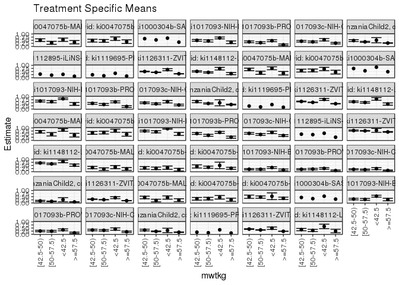

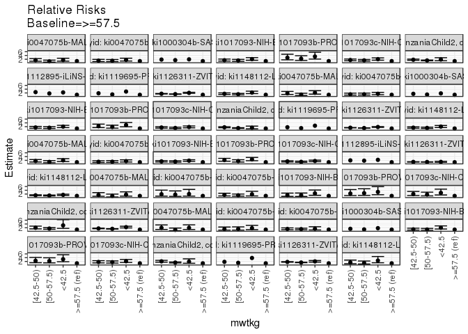

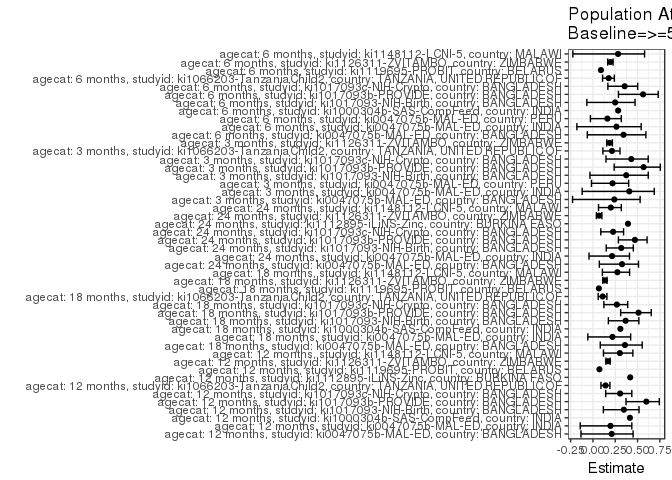

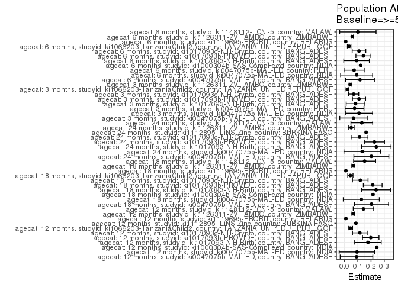

## Results Table

### Parameter: TSM

| agecat | studyid | country | intervention_level | baseline_level | estimate | ci_lower | ci_upper |
| --- | --- | --- | --- | --- | --- | --- | --- |
| 3 months | ki0047075b-MAL-ED | BANGLADESH | >=57.5 | NA | 0.2156863 | 0.1025828 | 0.3287897 |
| 3 months | ki0047075b-MAL-ED | BANGLADESH | <42.5 | NA | 0.3636364 | 0.2362539 | 0.4910188 |
| 3 months | ki0047075b-MAL-ED | BANGLADESH | [42.5-50) | NA | 0.3258427 | 0.2282776 | 0.4234078 |
| 3 months | ki0047075b-MAL-ED | BANGLADESH | [50-57.5) | NA | 0.2033898 | 0.1004778 | 0.3063019 |
| 3 months | ki0047075b-MAL-ED | INDIA | >=57.5 | NA | 0.1590909 | 0.0507935 | 0.2673883 |
| 3 months | ki0047075b-MAL-ED | INDIA | <42.5 | NA | 0.3191489 | 0.1856059 | 0.4526919 |
| 3 months | ki0047075b-MAL-ED | INDIA | [42.5-50) | NA | 0.3026316 | 0.1991344 | 0.4061288 |
| 3 months | ki0047075b-MAL-ED | INDIA | [50-57.5) | NA | 0.2666667 | 0.1663780 | 0.3669553 |
| 3 months | ki0047075b-MAL-ED | PERU | >=57.5 | NA | 0.2692308 | 0.1838355 | 0.3546261 |
| 3 months | ki0047075b-MAL-ED | PERU | <42.5 | NA | 0.5000000 | 0.2376361 | 0.7623639 |
| 3 months | ki0047075b-MAL-ED | PERU | [42.5-50) | NA | 0.4210526 | 0.2926575 | 0.5494477 |
| 3 months | ki0047075b-MAL-ED | PERU | [50-57.5) | NA | 0.3565217 | 0.2688299 | 0.4442136 |
| 3 months | ki1017093-NIH-Birth | BANGLADESH | >=57.5 | NA | 0.1395349 | 0.0662436 | 0.2128262 |
| 3 months | ki1017093-NIH-Birth | BANGLADESH | <42.5 | NA | 0.3275862 | 0.2577951 | 0.3973773 |
| 3 months | ki1017093-NIH-Birth | BANGLADESH | [42.5-50) | NA | 0.1935484 | 0.1409409 | 0.2461559 |
| 3 months | ki1017093-NIH-Birth | BANGLADESH | [50-57.5) | NA | 0.1907895 | 0.1282751 | 0.2533038 |
| 3 months | ki1017093b-PROVIDE | BANGLADESH | >=57.5 | NA | 0.0833333 | 0.0338456 | 0.1328210 |
| 3 months | ki1017093b-PROVIDE | BANGLADESH | <42.5 | NA | 0.2598870 | 0.1952282 | 0.3245458 |
| 3 months | ki1017093b-PROVIDE | BANGLADESH | [42.5-50) | NA | 0.1881188 | 0.1341852 | 0.2420524 |
| 3 months | ki1017093b-PROVIDE | BANGLADESH | [50-57.5) | NA | 0.2058824 | 0.1450548 | 0.2667099 |
| 3 months | ki1017093c-NIH-Crypto | BANGLADESH | >=57.5 | NA | 0.0913706 | 0.0511082 | 0.1316329 |
| 3 months | ki1017093c-NIH-Crypto | BANGLADESH | <42.5 | NA | 0.2403846 | 0.1582040 | 0.3225652 |
| 3 months | ki1017093c-NIH-Crypto | BANGLADESH | [42.5-50) | NA | 0.1829787 | 0.1335113 | 0.2324461 |
| 3 months | ki1017093c-NIH-Crypto | BANGLADESH | [50-57.5) | NA | 0.1598174 | 0.1112536 | 0.2083812 |
| 3 months | ki1066203-TanzaniaChild2 | TANZANIA, UNITED REPUBLIC OF | >=57.5 | NA | 0.0797297 | 0.0659266 | 0.0935329 |
| 3 months | ki1066203-TanzaniaChild2 | TANZANIA, UNITED REPUBLIC OF | <42.5 | NA | 0.2592593 | 0.0939265 | 0.4245920 |
| 3 months | ki1066203-TanzaniaChild2 | TANZANIA, UNITED REPUBLIC OF | [42.5-50) | NA | 0.1603774 | 0.1109706 | 0.2097841 |
| 3 months | ki1066203-TanzaniaChild2 | TANZANIA, UNITED REPUBLIC OF | [50-57.5) | NA | 0.1253968 | 0.0995314 | 0.1512622 |
| 3 months | ki1126311-ZVITAMBO | ZIMBABWE | >=57.5 | NA | 0.1836499 | 0.1738967 | 0.1934030 |
| 3 months | ki1126311-ZVITAMBO | ZIMBABWE | <42.5 | NA | 0.4238411 | 0.3450183 | 0.5026638 |

[output cut: 162 more lines]

### Parameter: E(Y)

| agecat | studyid | country | intervention_level | baseline_level | estimate | ci_lower | ci_upper |
| --- | --- | --- | --- | --- | --- | --- | --- |
| 3 months | ki0047075b-MAL-ED | BANGLADESH | NA | NA | 0.2834646 | 0.2279309 | 0.3389982 |
| 3 months | ki0047075b-MAL-ED | INDIA | NA | NA | 0.2685950 | 0.2126364 | 0.3245537 |
| 3 months | ki0047075b-MAL-ED | PERU | NA | NA | 0.3448276 | 0.2900279 | 0.3996273 |
| 3 months | ki1017093-NIH-Birth | BANGLADESH | NA | NA | 0.2225755 | 0.1900416 | 0.2551094 |
| 3 months | ki1017093b-PROVIDE | BANGLADESH | NA | NA | 0.1928251 | 0.1629076 | 0.2227426 |
| 3 months | ki1017093c-NIH-Crypto | BANGLADESH | NA | NA | 0.1602649 | 0.1340799 | 0.1864499 |
| 3 months | ki1066203-TanzaniaChild2 | TANZANIA, UNITED REPUBLIC OF | NA | NA | 0.1013197 | 0.0891144 | 0.1135250 |
| 3 months | ki1126311-ZVITAMBO | ZIMBABWE | NA | NA | 0.2259422 | 0.2181867 | 0.2336976 |
| 6 months | ki0047075b-MAL-ED | BANGLADESH | NA | NA | 0.3414634 | 0.2820852 | 0.4008416 |
| 6 months | ki0047075b-MAL-ED | INDIA | NA | NA | 0.3472803 | 0.2867932 | 0.4077675 |
| 6 months | ki0047075b-MAL-ED | PERU | NA | NA | 0.4448399 | 0.3866322 | 0.5030475 |
| 6 months | ki1000304b-SAS-CompFeed | INDIA | NA | NA | 0.4289617 | NA | NA |
| 6 months | ki1017093-NIH-Birth | BANGLADESH | NA | NA | 0.3647913 | 0.3245616 | 0.4050210 |
| 6 months | ki1017093b-PROVIDE | BANGLADESH | NA | NA | 0.2535211 | 0.2197649 | 0.2872773 |
| 6 months | ki1017093c-NIH-Crypto | BANGLADESH | NA | NA | 0.3070652 | 0.2737175 | 0.3404129 |
| 6 months | ki1066203-TanzaniaChild2 | TANZANIA, UNITED REPUBLIC OF | NA | NA | 0.1991796 | 0.1824641 | 0.2158951 |
| 6 months | ki1119695-PROBIT | BELARUS | NA | NA | 0.1023477 | NA | NA |
| 6 months | ki1126311-ZVITAMBO | ZIMBABWE | NA | NA | 0.2977468 | 0.2880121 | 0.3074816 |
| 6 months | ki1148112-LCNI-5 | MALAWI | NA | NA | 0.3579336 | 0.3007518 | 0.4151153 |
| 12 months | ki0047075b-MAL-ED | BANGLADESH | NA | NA | 0.4309623 | 0.3680480 | 0.4938767 |
| 12 months | ki0047075b-MAL-ED | INDIA | NA | NA | 0.4743590 | 0.4102427 | 0.5384753 |
| 12 months | ki1000304b-SAS-CompFeed | INDIA | NA | NA | 0.5872642 | NA | NA |
| 12 months | ki1017093-NIH-Birth | BANGLADESH | NA | NA | 0.5101664 | 0.4680034 | 0.5523294 |
| 12 months | ki1017093b-PROVIDE | BANGLADESH | NA | NA | 0.3305921 | 0.2931685 | 0.3680157 |
| 12 months | ki1017093c-NIH-Crypto | BANGLADESH | NA | NA | 0.3799726 | 0.3447141 | 0.4152311 |
| 12 months | ki1066203-TanzaniaChild2 | TANZANIA, UNITED REPUBLIC OF | NA | NA | 0.3168114 | 0.2961940 | 0.3374289 |
| 12 months | ki1112895-iLiNS-Zinc | BURKINA FASO | NA | NA | 0.2056555 | NA | NA |
| 12 months | ki1119695-PROBIT | BELARUS | NA | NA | 0.1410199 | NA | NA |
| 12 months | ki1126311-ZVITAMBO | ZIMBABWE | NA | NA | 0.3833440 | 0.3735032 | 0.3931848 |
| 12 months | ki1148112-LCNI-5 | MALAWI | NA | NA | 0.4735547 | 0.4392122 | 0.5078972 |
| 18 months | ki0047075b-MAL-ED | BANGLADESH | NA | NA | 0.5670996 | 0.5030660 | 0.6311332 |
| 18 months | ki0047075b-MAL-ED | INDIA | NA | NA | 0.5789474 | 0.5147196 | 0.6431751 |
| 18 months | ki1000304b-SAS-CompFeed | INDIA | NA | NA | 0.6987952 | NA | NA |
| 18 months | ki1017093-NIH-Birth | BANGLADESH | NA | NA | 0.6498994 | 0.6079209 | 0.6918779 |
| 18 months | ki1017093b-PROVIDE | BANGLADESH | NA | NA | 0.4162521 | 0.3768752 | 0.4556289 |
| 18 months | ki1017093c-NIH-Crypto | BANGLADESH | NA | NA | 0.4433566 | 0.4069178 | 0.4797954 |
| 18 months | ki1066203-TanzaniaChild2 | TANZANIA, UNITED REPUBLIC OF | NA | NA | 0.4060309 | 0.3805331 | 0.4315286 |
| 18 months | ki1119695-PROBIT | BELARUS | NA | NA | 0.1534475 | NA | NA |
| 18 months | ki1126311-ZVITAMBO | ZIMBABWE | NA | NA | 0.4939991 | 0.4820702 | 0.5059280 |
| 18 months | ki1148112-LCNI-5 | MALAWI | NA | NA | 0.5534125 | 0.5158531 | 0.5909718 |
| 24 months | ki0047075b-MAL-ED | BANGLADESH | NA | NA | 0.6210046 | 0.5566048 | 0.6854043 |
| 24 months | ki0047075b-MAL-ED | INDIA | NA | NA | 0.6211454 | 0.5579003 | 0.6843905 |
| 24 months | ki1017093-NIH-Birth | BANGLADESH | NA | NA | 0.7553191 | 0.7164122 | 0.7942261 |
| 24 months | ki1017093b-PROVIDE | BANGLADESH | NA | NA | 0.4802065 | 0.4395469 | 0.5208662 |
| 24 months | ki1017093c-NIH-Crypto | BANGLADESH | NA | NA | 0.5015773 | 0.4626267 | 0.5405279 |
| 24 months | ki1112895-iLiNS-Zinc | BURKINA FASO | NA | NA | 0.4144981 | NA | NA |
| 24 months | ki1126311-ZVITAMBO | ZIMBABWE | NA | NA | 0.7264908 | 0.7055641 | 0.7474175 |
| 24 months | ki1148112-LCNI-5 | MALAWI | NA | NA | 0.6519337 | 0.6172111 | 0.6866563 |

### Parameter: RR

| agecat | studyid | country | intervention_level | baseline_level | estimate | ci_lower | ci_upper |
| --- | --- | --- | --- | --- | --- | --- | --- |
| 3 months | ki0047075b-MAL-ED | BANGLADESH | >=57.5 | >=57.5 | 1.0000000 | 1.0000000 | 1.000000 |
| 3 months | ki0047075b-MAL-ED | BANGLADESH | <42.5 | >=57.5 | 1.6859504 | 0.8973574 | 3.167555 |
| 3 months | ki0047075b-MAL-ED | BANGLADESH | [42.5-50) | >=57.5 | 1.5107252 | 0.8259155 | 2.763347 |
| 3 months | ki0047075b-MAL-ED | BANGLADESH | [50-57.5) | >=57.5 | 0.9429892 | 0.4550262 | 1.954236 |
| 3 months | ki0047075b-MAL-ED | INDIA | >=57.5 | >=57.5 | 1.0000000 | 1.0000000 | 1.000000 |
| 3 months | ki0047075b-MAL-ED | INDIA | <42.5 | >=57.5 | 2.0060790 | 0.9022487 | 4.460359 |
| 3 months | ki0047075b-MAL-ED | INDIA | [42.5-50) | >=57.5 | 1.9022556 | 0.8880170 | 4.074896 |
| 3 months | ki0047075b-MAL-ED | INDIA | [50-57.5) | >=57.5 | 1.6761905 | 0.7701404 | 3.648185 |
| 3 months | ki0047075b-MAL-ED | PERU | >=57.5 | >=57.5 | 1.0000000 | 1.0000000 | 1.000000 |
| 3 months | ki0047075b-MAL-ED | PERU | <42.5 | >=57.5 | 1.8571429 | 1.0059138 | 3.428703 |
| 3 months | ki0047075b-MAL-ED | PERU | [42.5-50) | >=57.5 | 1.5639098 | 1.0072238 | 2.428272 |
| 3 months | ki0047075b-MAL-ED | PERU | [50-57.5) | >=57.5 | 1.3242236 | 0.8864322 | 1.978232 |
| 3 months | ki1017093-NIH-Birth | BANGLADESH | >=57.5 | >=57.5 | 1.0000000 | 1.0000000 | 1.000000 |
| 3 months | ki1017093-NIH-Birth | BANGLADESH | <42.5 | >=57.5 | 2.3477011 | 1.3319182 | 4.138167 |
| 3 months | ki1017093-NIH-Birth | BANGLADESH | [42.5-50) | >=57.5 | 1.3870968 | 0.7678193 | 2.505847 |
| 3 months | ki1017093-NIH-Birth | BANGLADESH | [50-57.5) | >=57.5 | 1.3673246 | 0.7362252 | 2.539408 |
| 3 months | ki1017093b-PROVIDE | BANGLADESH | >=57.5 | >=57.5 | 1.0000000 | 1.0000000 | 1.000000 |
| 3 months | ki1017093b-PROVIDE | BANGLADESH | <42.5 | >=57.5 | 3.1186441 | 1.6380964 | 5.937343 |
| 3 months | ki1017093b-PROVIDE | BANGLADESH | [42.5-50) | >=57.5 | 2.2574257 | 1.1674102 | 4.365193 |
| 3 months | ki1017093b-PROVIDE | BANGLADESH | [50-57.5) | >=57.5 | 2.4705882 | 1.2727356 | 4.795816 |
| 3 months | ki1017093c-NIH-Crypto | BANGLADESH | >=57.5 | >=57.5 | 1.0000000 | 1.0000000 | 1.000000 |
| 3 months | ki1017093c-NIH-Crypto | BANGLADESH | <42.5 | >=57.5 | 2.6308758 | 1.5062155 | 4.595297 |
| 3 months | ki1017093c-NIH-Crypto | BANGLADESH | [42.5-50) | >=57.5 | 2.0026003 | 1.1941998 | 3.358239 |
| 3 months | ki1017093c-NIH-Crypto | BANGLADESH | [50-57.5) | >=57.5 | 1.7491120 | 1.0241293 | 2.987311 |
| 3 months | ki1066203-TanzaniaChild2 | TANZANIA, UNITED REPUBLIC OF | >=57.5 | >=57.5 | 1.0000000 | 1.0000000 | 1.000000 |
| 3 months | ki1066203-TanzaniaChild2 | TANZANIA, UNITED REPUBLIC OF | <42.5 | >=57.5 | 3.2517263 | 1.6793253 | 6.296412 |
| 3 months | ki1066203-TanzaniaChild2 | TANZANIA, UNITED REPUBLIC OF | [42.5-50) | >=57.5 | 2.0115126 | 1.4127082 | 2.864132 |
| 3 months | ki1066203-TanzaniaChild2 | TANZANIA, UNITED REPUBLIC OF | [50-57.5) | >=57.5 | 1.5727737 | 1.2014728 | 2.058821 |
| 3 months | ki1126311-ZVITAMBO | ZIMBABWE | >=57.5 | >=57.5 | 1.0000000 | 1.0000000 | 1.000000 |
| 3 months | ki1126311-ZVITAMBO | ZIMBABWE | <42.5 | >=57.5 | 2.3078756 | 1.9020281 | 2.800321 |

[output cut: 162 more lines]

### Parameter: PAR

| agecat | studyid | country | intervention_level | baseline_level | estimate | ci_lower | ci_upper |
| --- | --- | --- | --- | --- | --- | --- | --- |
| 3 months | ki0047075b-MAL-ED | BANGLADESH | >=57.5 | NA | 0.0677783 | -0.0358522 | 0.1714087 |
| 3 months | ki0047075b-MAL-ED | INDIA | >=57.5 | NA | 0.1095041 | 0.0065728 | 0.2124355 |
| 3 months | ki0047075b-MAL-ED | PERU | >=57.5 | NA | 0.0755968 | 0.0044281 | 0.1467655 |
| 3 months | ki1017093-NIH-Birth | BANGLADESH | >=57.5 | NA | 0.0830406 | 0.0126048 | 0.1534764 |
| 3 months | ki1017093b-PROVIDE | BANGLADESH | >=57.5 | NA | 0.1094918 | 0.0598378 | 0.1591457 |
| 3 months | ki1017093c-NIH-Crypto | BANGLADESH | >=57.5 | NA | 0.0688943 | 0.0306745 | 0.1071142 |
| 3 months | ki1066203-TanzaniaChild2 | TANZANIA, UNITED REPUBLIC OF | >=57.5 | NA | 0.0215900 | 0.0116194 | 0.0315605 |
| 3 months | ki1126311-ZVITAMBO | ZIMBABWE | >=57.5 | NA | 0.0422923 | 0.0350707 | 0.0495139 |
| 6 months | ki0047075b-MAL-ED | BANGLADESH | >=57.5 | NA | 0.1169736 | 0.0084814 | 0.2254659 |
| 6 months | ki0047075b-MAL-ED | INDIA | >=57.5 | NA | 0.0914664 | -0.0293306 | 0.2122634 |
| 6 months | ki0047075b-MAL-ED | PERU | >=57.5 | NA | 0.0722908 | -0.0039267 | 0.1485084 |
| 6 months | ki1000304b-SAS-CompFeed | INDIA | >=57.5 | NA | 0.1212694 | NA | NA |
| 6 months | ki1017093-NIH-Birth | BANGLADESH | >=57.5 | NA | 0.0908187 | -0.0057533 | 0.1873907 |
| 6 months | ki1017093b-PROVIDE | BANGLADESH | >=57.5 | NA | 0.1424100 | 0.0858594 | 0.1989607 |
| 6 months | ki1017093c-NIH-Crypto | BANGLADESH | >=57.5 | NA | 0.1091486 | 0.0578343 | 0.1604628 |
| 6 months | ki1066203-TanzaniaChild2 | TANZANIA, UNITED REPUBLIC OF | >=57.5 | NA | 0.0351395 | 0.0218538 | 0.0484251 |
| 6 months | ki1119695-PROBIT | BELARUS | >=57.5 | NA | 0.0091518 | NA | NA |
| 6 months | ki1126311-ZVITAMBO | ZIMBABWE | >=57.5 | NA | 0.0583588 | 0.0493893 | 0.0673282 |
| 6 months | ki1148112-LCNI-5 | MALAWI | >=57.5 | NA | 0.1007907 | -0.0366047 | 0.2381861 |
| 12 months | ki0047075b-MAL-ED | BANGLADESH | >=57.5 | NA | 0.0905368 | -0.0325042 | 0.2135778 |
| 12 months | ki0047075b-MAL-ED | INDIA | >=57.5 | NA | 0.0934066 | -0.0407459 | 0.2275591 |
| 12 months | ki1000304b-SAS-CompFeed | INDIA | >=57.5 | NA | 0.2435142 | NA | NA |
| 12 months | ki1017093-NIH-Birth | BANGLADESH | >=57.5 | NA | 0.1768330 | 0.0767371 | 0.2769290 |
| 12 months | ki1017093b-PROVIDE | BANGLADESH | >=57.5 | NA | 0.1978487 | 0.1356920 | 0.2600055 |
| 12 months | ki1017093c-NIH-Crypto | BANGLADESH | >=57.5 | NA | 0.1157239 | 0.0603487 | 0.1710990 |
| 12 months | ki1066203-TanzaniaChild2 | TANZANIA, UNITED REPUBLIC OF | >=57.5 | NA | 0.0448114 | 0.0288069 | 0.0608159 |
| 12 months | ki1112895-iLiNS-Zinc | BURKINA FASO | >=57.5 | NA | 0.0858399 | NA | NA |
| 12 months | ki1119695-PROBIT | BELARUS | >=57.5 | NA | 0.0102970 | NA | NA |
| 12 months | ki1126311-ZVITAMBO | ZIMBABWE | >=57.5 | NA | 0.0650008 | 0.0558640 | 0.0741376 |
| 12 months | ki1148112-LCNI-5 | MALAWI | >=57.5 | NA | 0.1429096 | 0.0657724 | 0.2200467 |
| 18 months | ki0047075b-MAL-ED | BANGLADESH | >=57.5 | NA | 0.2034632 | 0.0743845 | 0.3325419 |
| 18 months | ki0047075b-MAL-ED | INDIA | >=57.5 | NA | 0.1265664 | -0.0094440 | 0.2625768 |
| 18 months | ki1000304b-SAS-CompFeed | INDIA | >=57.5 | NA | 0.2149242 | NA | NA |
| 18 months | ki1017093-NIH-Birth | BANGLADESH | >=57.5 | NA | 0.2381347 | 0.1298705 | 0.3463989 |
| 18 months | ki1017093b-PROVIDE | BANGLADESH | >=57.5 | NA | 0.2127122 | 0.1419890 | 0.2834355 |
| 18 months | ki1017093c-NIH-Crypto | BANGLADESH | >=57.5 | NA | 0.1188886 | 0.0601157 | 0.1776614 |
| 18 months | ki1066203-TanzaniaChild2 | TANZANIA, UNITED REPUBLIC OF | >=57.5 | NA | 0.0442107 | 0.0244528 | 0.0639685 |
| 18 months | ki1119695-PROBIT | BELARUS | >=57.5 | NA | 0.0101997 | NA | NA |
| 18 months | ki1126311-ZVITAMBO | ZIMBABWE | >=57.5 | NA | 0.0664545 | 0.0548785 | 0.0780306 |
| 18 months | ki1148112-LCNI-5 | MALAWI | >=57.5 | NA | 0.1516267 | 0.0684226 | 0.2348309 |
| 24 months | ki0047075b-MAL-ED | BANGLADESH | >=57.5 | NA | 0.2023999 | 0.0704451 | 0.3343547 |
| 24 months | ki0047075b-MAL-ED | INDIA | >=57.5 | NA | 0.1333405 | -0.0045702 | 0.2712512 |
| 24 months | ki1017093-NIH-Birth | BANGLADESH | >=57.5 | NA | 0.2396941 | 0.1281353 | 0.3512530 |
| 24 months | ki1017093b-PROVIDE | BANGLADESH | >=57.5 | NA | 0.2256611 | 0.1496500 | 0.3016722 |
| 24 months | ki1017093c-NIH-Crypto | BANGLADESH | >=57.5 | NA | 0.1133420 | 0.0500186 | 0.1766654 |
| 24 months | ki1112895-iLiNS-Zinc | BURKINA FASO | >=57.5 | NA | 0.1627975 | NA | NA |
| 24 months | ki1126311-ZVITAMBO | ZIMBABWE | >=57.5 | NA | 0.0506535 | 0.0287558 | 0.0725512 |
| 24 months | ki1148112-LCNI-5 | MALAWI | >=57.5 | NA | 0.1305662 | 0.0483562 | 0.2127762 |

### Parameter: PAF

| agecat | studyid | country | intervention_level | baseline_level | estimate | ci_lower | ci_upper |
| --- | --- | --- | --- | --- | --- | --- | --- |
| 3 months | ki0047075b-MAL-ED | BANGLADESH | >=57.5 | NA | 0.2391068 | -0.2283035 | 0.5286519 |
| 3 months | ki0047075b-MAL-ED | INDIA | >=57.5 | NA | 0.4076923 | -0.1210057 | 0.6870414 |
| 3 months | ki0047075b-MAL-ED | PERU | >=57.5 | NA | 0.2192308 | -0.0163252 | 0.4001914 |
| 3 months | ki1017093-NIH-Birth | BANGLADESH | >=57.5 | NA | 0.3730897 | -0.0335611 | 0.6197452 |
| 3 months | ki1017093b-PROVIDE | BANGLADESH | >=57.5 | NA | 0.5678295 | 0.2377144 | 0.7549850 |
| 3 months | ki1017093c-NIH-Crypto | BANGLADESH | >=57.5 | NA | 0.4298779 | 0.1461951 | 0.6193050 |
| 3 months | ki1066203-TanzaniaChild2 | TANZANIA, UNITED REPUBLIC OF | >=57.5 | NA | 0.2130877 | 0.1114232 | 0.3031204 |
| 3 months | ki1126311-ZVITAMBO | ZIMBABWE | >=57.5 | NA | 0.1871819 | 0.1549379 | 0.2181957 |
| 6 months | ki0047075b-MAL-ED | BANGLADESH | >=57.5 | NA | 0.3425656 | -0.0630719 | 0.5934236 |
| 6 months | ki0047075b-MAL-ED | INDIA | >=57.5 | NA | 0.2633791 | -0.1801434 | 0.5402166 |
| 6 months | ki0047075b-MAL-ED | PERU | >=57.5 | NA | 0.1625098 | -0.0281659 | 0.3178243 |
| 6 months | ki1000304b-SAS-CompFeed | INDIA | >=57.5 | NA | 0.2827046 | NA | NA |
| 6 months | ki1017093-NIH-Birth | BANGLADESH | >=57.5 | NA | 0.2489607 | -0.0681519 | 0.4719290 |
| 6 months | ki1017093b-PROVIDE | BANGLADESH | >=57.5 | NA | 0.5617284 | 0.2857109 | 0.7310865 |
| 6 months | ki1017093c-NIH-Crypto | BANGLADESH | >=57.5 | NA | 0.3554572 | 0.1671697 | 0.5011764 |
| 6 months | ki1066203-TanzaniaChild2 | TANZANIA, UNITED REPUBLIC OF | >=57.5 | NA | 0.1764210 | 0.1080025 | 0.2395916 |
| 6 months | ki1119695-PROBIT | BELARUS | >=57.5 | NA | 0.0894190 | NA | NA |
| 6 months | ki1126311-ZVITAMBO | ZIMBABWE | >=57.5 | NA | 0.1960013 | 0.1655315 | 0.2253586 |
| 6 months | ki1148112-LCNI-5 | MALAWI | >=57.5 | NA | 0.2815906 | -0.2249121 | 0.5786538 |
| 12 months | ki0047075b-MAL-ED | BANGLADESH | >=57.5 | NA | 0.2100806 | -0.1343026 | 0.4499063 |
| 12 months | ki0047075b-MAL-ED | INDIA | >=57.5 | NA | 0.1969112 | -0.1428905 | 0.4356838 |
| 12 months | ki1000304b-SAS-CompFeed | INDIA | >=57.5 | NA | 0.4146586 | NA | NA |
| 12 months | ki1017093-NIH-Birth | BANGLADESH | >=57.5 | NA | 0.3466184 | 0.1167551 | 0.5166600 |
| 12 months | ki1017093b-PROVIDE | BANGLADESH | >=57.5 | NA | 0.5984678 | 0.3705673 | 0.7438518 |
| 12 months | ki1017093c-NIH-Crypto | BANGLADESH | >=57.5 | NA | 0.3045585 | 0.1429284 | 0.4357077 |
| 12 months | ki1066203-TanzaniaChild2 | TANZANIA, UNITED REPUBLIC OF | >=57.5 | NA | 0.1414452 | 0.0895934 | 0.1903437 |
| 12 months | ki1112895-iLiNS-Zinc | BURKINA FASO | >=57.5 | NA | 0.4173963 | NA | NA |
| 12 months | ki1119695-PROBIT | BELARUS | >=57.5 | NA | 0.0730181 | NA | NA |
| 12 months | ki1126311-ZVITAMBO | ZIMBABWE | >=57.5 | NA | 0.1695626 | 0.1453695 | 0.1930708 |
| 12 months | ki1148112-LCNI-5 | MALAWI | >=57.5 | NA | 0.3017805 | 0.1178473 | 0.4473627 |
| 18 months | ki0047075b-MAL-ED | BANGLADESH | >=57.5 | NA | 0.3587786 | 0.0820491 | 0.5520841 |
| 18 months | ki0047075b-MAL-ED | INDIA | >=57.5 | NA | 0.2186147 | -0.0573890 | 0.4225749 |
| 18 months | ki1000304b-SAS-CompFeed | INDIA | >=57.5 | NA | 0.3075640 | NA | NA |
| 18 months | ki1017093-NIH-Birth | BANGLADESH | >=57.5 | NA | 0.3664178 | 0.1729366 | 0.5146364 |
| 18 months | ki1017093b-PROVIDE | BANGLADESH | >=57.5 | NA | 0.5110179 | 0.3108151 | 0.6530633 |
| 18 months | ki1017093c-NIH-Crypto | BANGLADESH | >=57.5 | NA | 0.2681556 | 0.1224635 | 0.3896593 |
| 18 months | ki1066203-TanzaniaChild2 | TANZANIA, UNITED REPUBLIC OF | >=57.5 | NA | 0.1088850 | 0.0587603 | 0.1563403 |
| 18 months | ki1119695-PROBIT | BELARUS | >=57.5 | NA | 0.0664701 | NA | NA |
| 18 months | ki1126311-ZVITAMBO | ZIMBABWE | >=57.5 | NA | 0.1345236 | 0.1106110 | 0.1577933 |
| 18 months | ki1148112-LCNI-5 | MALAWI | >=57.5 | NA | 0.2739851 | 0.1058096 | 0.4105308 |
| 24 months | ki0047075b-MAL-ED | BANGLADESH | >=57.5 | NA | 0.3259234 | 0.0717008 | 0.5105250 |
| 24 months | ki0047075b-MAL-ED | INDIA | >=57.5 | NA | 0.2146687 | -0.0441646 | 0.4093410 |
| 24 months | ki1017093-NIH-Birth | BANGLADESH | >=57.5 | NA | 0.3173415 | 0.1488658 | 0.4524688 |
| 24 months | ki1017093b-PROVIDE | BANGLADESH | >=57.5 | NA | 0.4699251 | 0.2856028 | 0.6066902 |
| 24 months | ki1017093c-NIH-Crypto | BANGLADESH | >=57.5 | NA | 0.2259711 | 0.0880443 | 0.3430375 |
| 24 months | ki1112895-iLiNS-Zinc | BURKINA FASO | >=57.5 | NA | 0.3927580 | NA | NA |
| 24 months | ki1126311-ZVITAMBO | ZIMBABWE | >=57.5 | NA | 0.0697235 | 0.0388168 | 0.0996364 |
| 24 months | ki1148112-LCNI-5 | MALAWI | >=57.5 | NA | 0.2002752 | 0.0626367 | 0.3177035 |